# CSCI 4148 - Practical 0

### Q4

**Plot y vs. x for the circle dataset. You can (and should) reuse code we introduced above, just replace the dataset name with the desired dataset. Then, calculate the correlation coefficient between x and y for this dataset. How does this value compare to the r of dino?**

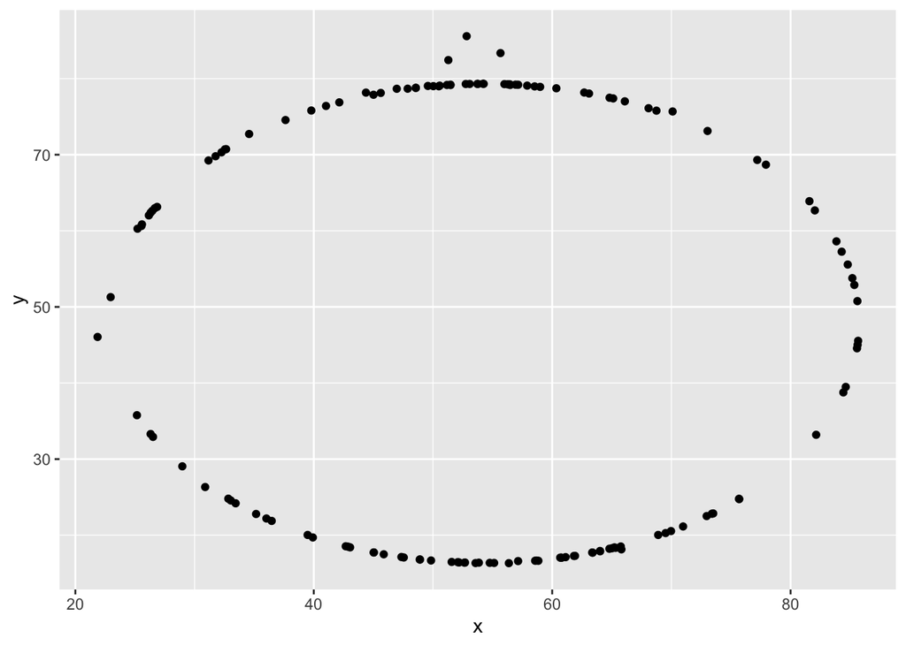

```r
star_data <- datasaurus_dozen %>%
  filter(dataset == "circle")

ggplot(data = star_data, mapping = aes(x = x, y = y)) +
  geom_point()
```

```r
star_data %>%
  summarise(r = cor(x, y))
```

| r |
| --- |
| -0.06834336 |

A: Again, the correlation coefficient is very low. Still on the order of 0.06.

### Q5

**Finally, let’s plot all datasets at once. In order to do this we will make use of facetting.**

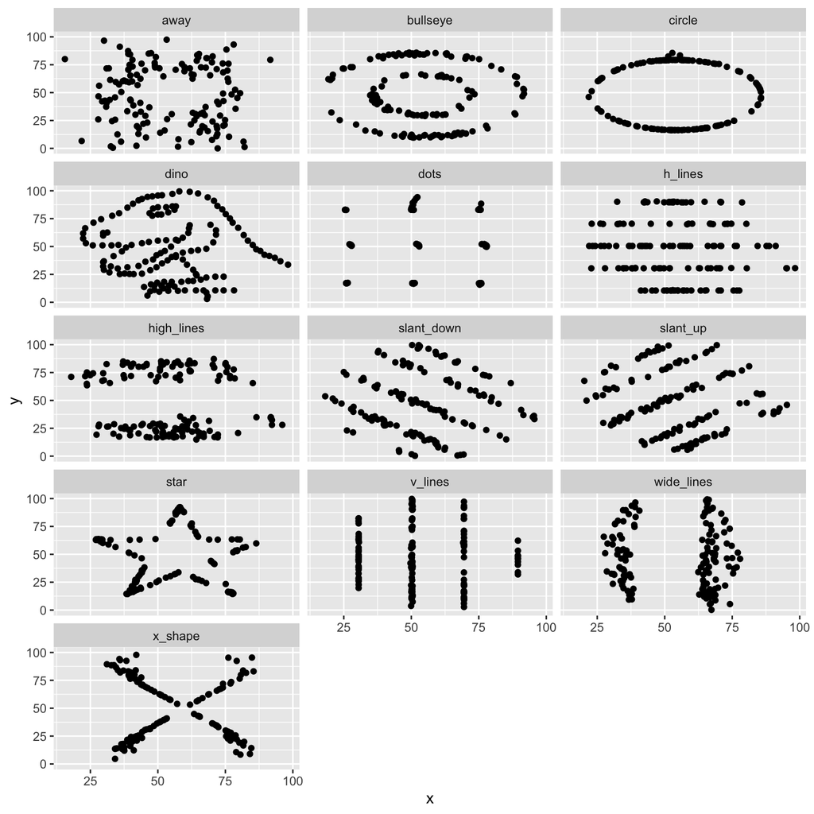

```r
ggplot(datasaurus_dozen, aes(x=x, y=y), color=dataset) +
  geom_point() +
  facet_wrap(~ dataset, ncol=3) +
  theme(legend.position="none")
```

```r
datasaurus_dozen %>%
  group_by(dataset) %>%
  summarise(r=cor(x, y))
```

| dataset | r |
| --- | --- |
| away | -0.06412835 |
| bullseye | -0.06858639 |
| circle | -0.06834336 |
| dino | -0.06447185 |
| dots | -0.06034144 |
| h_lines | -0.06171484 |
| high_lines | -0.06850422 |
| slant_down | -0.06897974 |
| slant_up | -0.06860921 |
| star | -0.06296110 |

[output cut: 3 more lines]